# Results: HW10_dignostics.sas

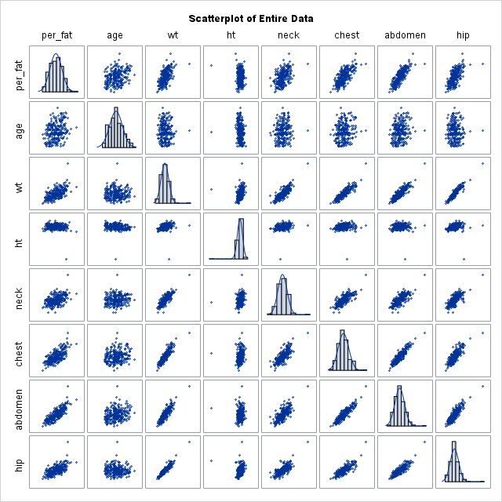

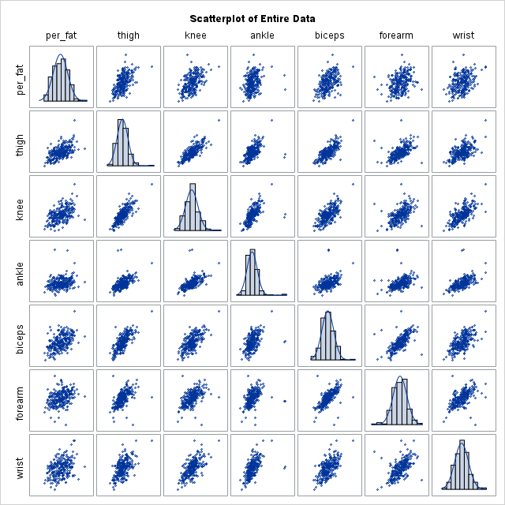

Simple Random Sampling of 40 values

The SURVEYSELECT Procedure

| Selection Method | Simple Random Sampling |
| --- | --- |

| Input Data Set | BODYFAT |
| --- | --- |
| Random Number Seed | 54321 |
| Sample Size | 40 |
| Selection Probability | 0.15873 |
| Sampling Weight | 6.3 |
| Output Data Set | NEW_BFAT |

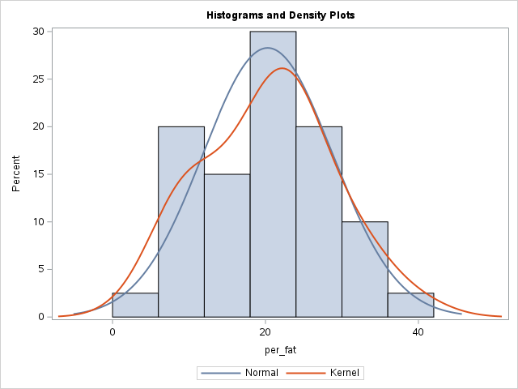

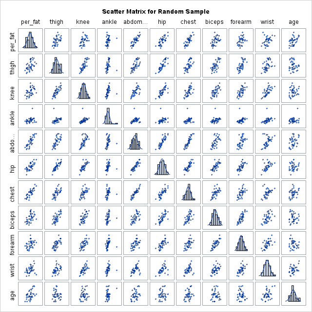

The REG Procedure

Model: MODEL1

Dependent Variable: per_fat

| Number of Observations Read | 40 |
| --- | --- |
| Number of Observations Used | 40 |

| Analysis of Variance Source | Analysis of Variance DF | Analysis of Variance Sum of Squares | Analysis of Variance Mean Square | Analysis of Variance F Value | Analysis of Variance Pr > F |
| --- | --- | --- | --- | --- | --- |
| Model | 1 | 627.00385 | 627.00385 | 10.99 | 0.0020 |
| Error | 38 | 2167.01990 | 57.02684 |  |  |
| Corrected Total | 39 | 2794.02375 |  |  |  |

| Root MSE | 7.55161 | R-Square | 0.2244 |
| --- | --- | --- | --- |
| Dependent Mean | 20.28750 | Adj R-Sq | 0.2040 |
| Coeff Var | 37.22298 |  |  |

| Parameter Estimates Variable | Parameter Estimates DF | Parameter Estimates Parameter Estimate | Parameter Estimates Standard Error | Parameter Estimates t Value | Parameter Estimates Pr > \|t\| |
| --- | --- | --- | --- | --- | --- |
| Intercept | 1 | -34.41393 | 16.54009 | -2.08 | 0.0443 |
| thigh | 1 | 0.91466 | 0.27585 | 3.32 | 0.0020 |

The REG Procedure

Model: MODEL1

Dependent Variable: per_fat

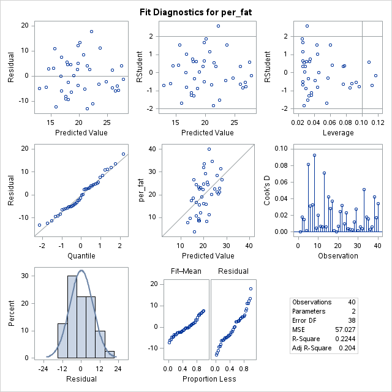

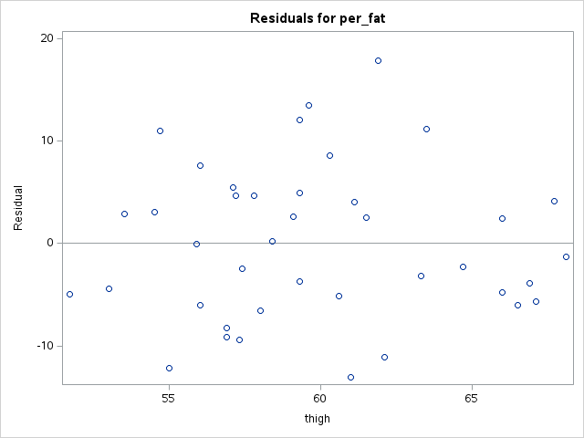

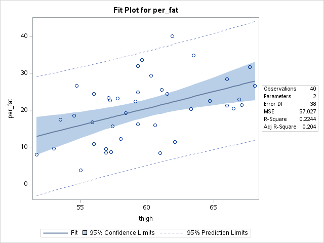

Polynomial Regression

The REG Procedure

Model: MODEL1

Dependent Variable: per_fat

| Number of Observations Read | 40 |
| --- | --- |
| Number of Observations Used | 40 |

| Analysis of Variance Source | Analysis of Variance DF | Analysis of Variance Sum of Squares | Analysis of Variance Mean Square | Analysis of Variance F Value | Analysis of Variance Pr > F |
| --- | --- | --- | --- | --- | --- |
| Model | 2 | 1932.57131 | 966.28566 | 41.50 | <.0001 |
| Error | 37 | 861.45244 | 23.28250 |  |  |
| Corrected Total | 39 | 2794.02375 |  |  |  |

| Root MSE | 4.82519 | R-Square | 0.6917 |
| --- | --- | --- | --- |
| Dependent Mean | 20.28750 | Adj R-Sq | 0.6750 |
| Coeff Var | 23.78407 |  |  |

| Parameter Estimates Variable | Parameter Estimates DF | Parameter Estimates Parameter Estimate | Parameter Estimates Standard Error | Parameter Estimates t Value | Parameter Estimates Pr > \|t\| | Parameter Estimates Type I SS |
| --- | --- | --- | --- | --- | --- | --- |
| Intercept | 1 | 0.61928 | 57.42502 | 0.01 | 0.9915 | 16463 |
| abdomen | 1 | -0.23325 | 1.22596 | -0.19 | 0.8501 | 1920.48466 |
| abdomen2 | 1 | 0.00467 | 0.00648 | 0.72 | 0.4757 | 12.08665 |

Polynomial Regression

The REG Procedure

Model: MODEL1

Dependent Variable: per_fat

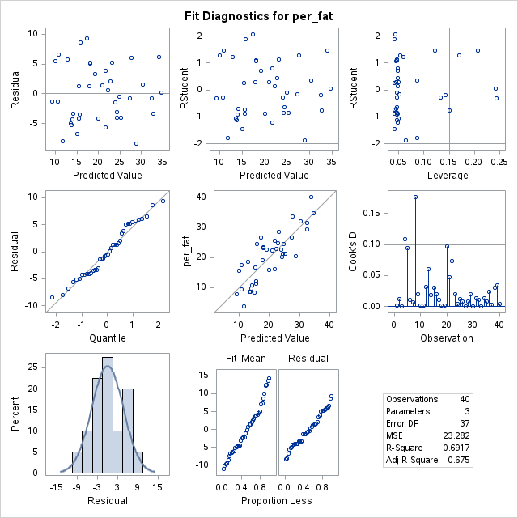

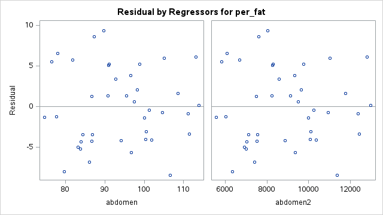

Polynomial Regression

The REG Procedure

Model: MODEL1

Partial Regression Residual Plot

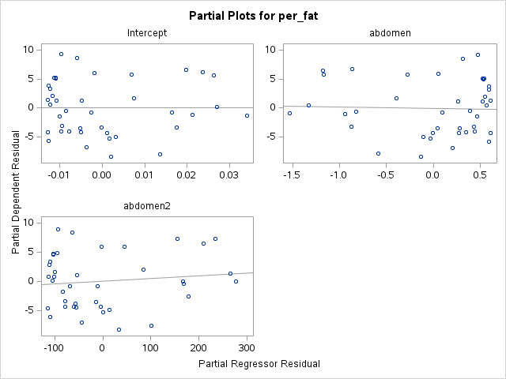

Multiple Regression Analysis

The REG Procedure

Model: MODEL1

Dependent Variable: per_fat

| Number of Observations Read | 40 |
| --- | --- |
| Number of Observations Used | 40 |

| Analysis of Variance Source | Analysis of Variance DF | Analysis of Variance Sum of Squares | Analysis of Variance Mean Square | Analysis of Variance F Value | Analysis of Variance Pr > F |
| --- | --- | --- | --- | --- | --- |
| Model | 10 | 2205.82714 | 220.58271 | 10.88 | <.0001 |
| Error | 29 | 588.19661 | 20.28264 |  |  |
| Corrected Total | 39 | 2794.02375 |  |  |  |

| Root MSE | 4.50363 | R-Square | 0.7895 |
| --- | --- | --- | --- |
| Dependent Mean | 20.28750 | Adj R-Sq | 0.7169 |
| Coeff Var | 22.19902 |  |  |

| Parameter Estimates Variable | Parameter Estimates DF | Parameter Estimates Parameter Estimate | Parameter Estimates Standard Error | Parameter Estimates t Value | Parameter Estimates Pr > \|t\| |
| --- | --- | --- | --- | --- | --- |
| Intercept | 1 | -43.13906 | 21.34025 | -2.02 | 0.0525 |
| thigh | 1 | -0.12706 | 0.40602 | -0.31 | 0.7566 |
| knee | 1 | -0.99785 | 0.71784 | -1.39 | 0.1751 |
| ankle | 1 | 0.41394 | 0.39613 | 1.04 | 0.3047 |
| abdomen | 1 | 0.25444 | 0.26469 | 0.96 | 0.3444 |
| hip | 1 | 0.53385 | 0.36426 | 1.47 | 0.1535 |
| chest | 1 | 0.30955 | 0.26296 | 1.18 | 0.2487 |
| biceps | 1 | 0.37224 | 0.51926 | 0.72 | 0.4792 |
| forearm | 1 | -0.34412 | 0.98429 | -0.35 | 0.7292 |
| wrist | 1 | -1.05353 | 1.52025 | -0.69 | 0.4938 |
| age | 1 | 0.17767 | 0.11347 | 1.57 | 0.1282 |

Multiple Regression Analysis

The REG Procedure

Model: MODEL1

Dependent Variable: per_fat

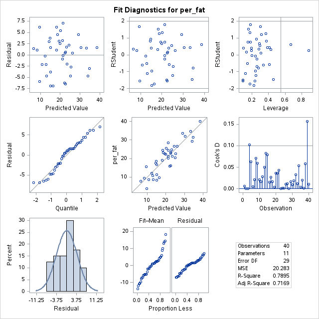

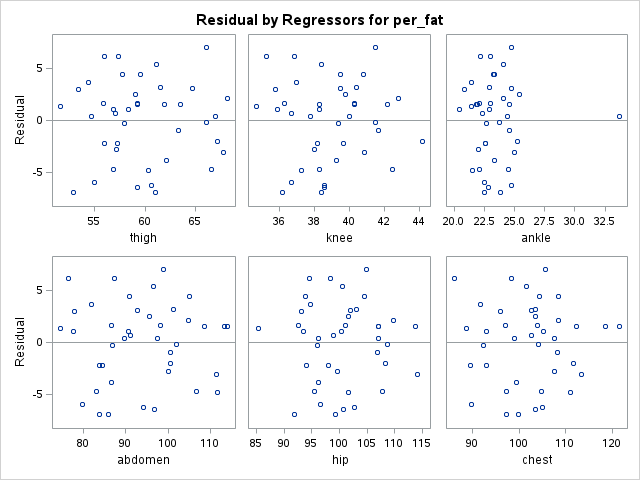

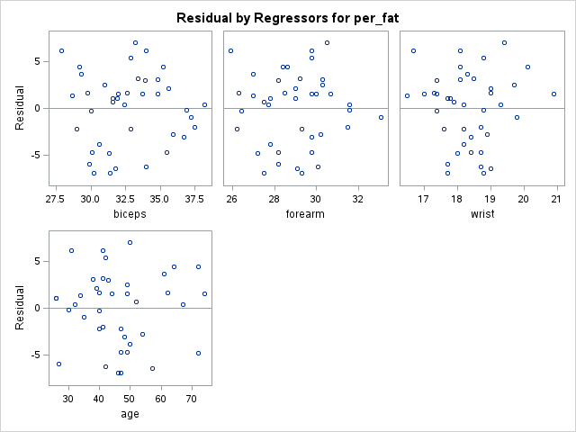

Ridge Regression and Collinearity Check

The REG Procedure

Model: MODEL1

Dependent Variable: per_fat

| Number of Observations Read | 40 |
| --- | --- |
| Number of Observations Used | 40 |

| Analysis of Variance Source | Analysis of Variance DF | Analysis of Variance Sum of Squares | Analysis of Variance Mean Square | Analysis of Variance F Value | Analysis of Variance Pr > F |
| --- | --- | --- | --- | --- | --- |
| Model | 10 | 2205.82714 | 220.58271 | 10.88 | <.0001 |
| Error | 29 | 588.19661 | 20.28264 |  |  |
| Corrected Total | 39 | 2794.02375 |  |  |  |

| Root MSE | 4.50363 | R-Square | 0.7895 |
| --- | --- | --- | --- |
| Dependent Mean | 20.28750 | Adj R-Sq | 0.7169 |
| Coeff Var | 22.19902 |  |  |

| Parameter Estimates Variable | Parameter Estimates DF | Parameter Estimates Parameter Estimate | Parameter Estimates Standard Error | Parameter Estimates t Value | Parameter Estimates Pr > \|t\| | Parameter Estimates Tolerance | Parameter Estimates Variance Inflation |
| --- | --- | --- | --- | --- | --- | --- | --- |
| Intercept | 1 | -43.13906 | 21.34025 | -2.02 | 0.0525 | . | 0 |
| thigh | 1 | -0.12706 | 0.40602 | -0.31 | 0.7566 | 0.16416 | 6.09147 |
| knee | 1 | -0.99785 | 0.71784 | -1.39 | 0.1751 | 0.20357 | 4.91238 |
| ankle | 1 | 0.41394 | 0.39613 | 1.04 | 0.3047 | 0.75142 | 1.33082 |
| abdomen | 1 | 0.25444 | 0.26469 | 0.96 | 0.3444 | 0.06341 | 15.77118 |
| hip | 1 | 0.53385 | 0.36426 | 1.47 | 0.1535 | 0.09638 | 10.37529 |
| chest | 1 | 0.30955 | 0.26296 | 1.18 | 0.2487 | 0.11422 | 8.75483 |
| biceps | 1 | 0.37224 | 0.51926 | 0.72 | 0.4792 | 0.26499 | 3.77367 |
| forearm | 1 | -0.34412 | 0.98429 | -0.35 | 0.7292 | 0.19639 | 5.09181 |
| wrist | 1 | -1.05353 | 1.52025 | -0.69 | 0.4938 | 0.26954 | 3.71002 |
| age | 1 | 0.17767 | 0.11347 | 1.57 | 0.1282 | 0.25779 | 3.87913 |

| Collinearity Diagnostics Number | Collinearity Diagnostics Eigenvalue | Collinearity Diagnostics Condition Index | Collinearity Diagnostics Proportion of Variation Intercept | Collinearity Diagnostics Proportion of Variation thigh | Collinearity Diagnostics Proportion of Variation knee | Collinearity Diagnostics Proportion of Variation ankle | Collinearity Diagnostics Proportion of Variation abdomen | Collinearity Diagnostics Proportion of Variation hip | Collinearity Diagnostics Proportion of Variation chest | Collinearity Diagnostics Proportion of Variation biceps | Collinearity Diagnostics Proportion of Variation forearm | Collinearity Diagnostics Proportion of Variation wrist | Collinearity Diagnostics Proportion of Variation age |
| --- | --- | --- | --- | --- | --- | --- | --- | --- | --- | --- | --- | --- | --- |
| 1 | 10.91706 | 1.00000 | 0.00000931 | 0.00000716 | 0.00000542 | 0.00004899 | 0.00000680 | 0.00000316 | 0.00000585 | 0.00001459 | 0.00000521 | 0.00000544 | 0.00013660 |
| 2 | 0.06089 | 13.39029 | 0.00016136 | 0.00041452 | 0.00009528 | 0.00013439 | 0.00000182 | 0.00008295 | 0.00001446 | 0.00086013 | 0.00027310 | 0.00001613 | 0.24813 |
| 3 | 0.01069 | 31.95322 | 0.00991 | 0.00102 | 0.00021561 | 0.18485 | 0.02830 | 0.00067262 | 0.00637 | 0.00136 | 0.00029740 | 0.00302 | 0.00084126 |
| 4 | 0.00448 | 49.35026 | 0.04817 | 0.00020803 | 0.00145 | 0.72027 | 0.01714 | 2.99764E-7 | 0.00006999 | 0.00038750 | 0.00582 | 0.01498 | 0.01632 |
| 5 | 0.00245 | 66.75317 | 0.04846 | 0.03799 | 0.00753 | 0.00486 | 0.00566 | 0.00500 | 0.00095561 | 0.42931 | 0.02055 | 0.00363 | 0.02791 |
| 6 | 0.00184 | 77.00412 | 0.10763 | 0.11183 | 0.06916 | 0.05019 | 0.00182 | 0.00004519 | 0.11166 | 0.00785 | 0.00703 | 0.01276 | 0.04463 |
| 7 | 0.00087485 | 111.70847 | 0.18737 | 0.10216 | 0.00333 | 0.01859 | 0.05277 | 0.00060954 | 0.00001731 | 0.44696 | 0.12124 | 0.20820 | 0.15840 |
| 8 | 0.00060538 | 134.28803 | 0.12594 | 0.26922 | 0.00095916 | 0.00033345 | 0.18978 | 0.07670 | 0.21895 | 0.07182 | 0.19590 | 0.07016 | 0.14212 |
| 9 | 0.00051235 | 145.97245 | 0.00098567 | 0.20607 | 0.66555 | 0.00002710 | 0.00026566 | 0.11307 | 0.13299 | 0.01749 | 0.10401 | 0.00274 | 0.14321 |
| 10 | 0.00033819 | 179.66804 | 0.01603 | 0.16855 | 0.22004 | 0.01341 | 0.01001 | 0.07356 | 0.25393 | 0.02130 | 0.47097 | 0.68289 | 0.19661 |
| 11 | 0.00025715 | 206.04424 | 0.45533 | 0.10254 | 0.03167 | 0.00729 | 0.69424 | 0.73026 | 0.27505 | 0.00265 | 0.07390 | 0.00159 | 0.02171 |

Ridge Regression and Collinearity Check

The REG Procedure

Model: MODEL1

Dependent Variable: per_fat

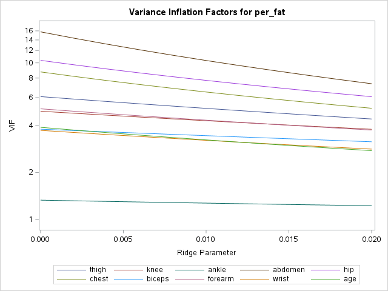

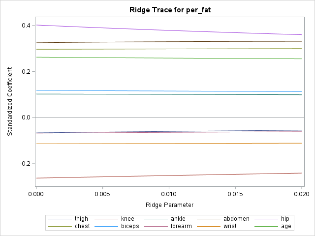

Forward Regression

The REG Procedure

Model: MODEL1

Dependent Variable: per_fat

| Number of Observations Read | 40 |
| --- | --- |
| Number of Observations Used | 40 |

Forward Selection: Step 1

Variable abdomen Entered: R-Square = 0.6874 and C(p) = 7.0683

| Analysis of Variance Source | Analysis of Variance DF | Analysis of Variance Sum of Squares | Analysis of Variance Mean Square | Analysis of Variance F Value | Analysis of Variance Pr > F |
| --- | --- | --- | --- | --- | --- |
| Model | 1 | 1920.48466 | 1920.48466 | 83.54 | <.0001 |
| Error | 38 | 873.53909 | 22.98787 |  |  |
| Corrected Total | 39 | 2794.02375 |  |  |  |

| Variable | Parameter Estimate | Standard Error | Type II SS | F Value | Pr > F |
| --- | --- | --- | --- | --- | --- |
| Intercept | -40.47046 | 6.69042 | 841.14086 | 36.59 | <.0001 |
| abdomen | 0.64857 | 0.07096 | 1920.48466 | 83.54 | <.0001 |

Bounds on condition number: 1, 1

Forward Selection: Step 2

Variable knee Entered: R-Square = 0.7223 and C(p) = 4.2578

| Analysis of Variance Source | Analysis of Variance DF | Analysis of Variance Sum of Squares | Analysis of Variance Mean Square | Analysis of Variance F Value | Analysis of Variance Pr > F |
| --- | --- | --- | --- | --- | --- |
| Model | 2 | 2018.05481 | 1009.02740 | 48.11 | <.0001 |
| Error | 37 | 775.96894 | 20.97213 |  |  |
| Corrected Total | 39 | 2794.02375 |  |  |  |

| Variable | Parameter Estimate | Standard Error | Type II SS | F Value | Pr > F |
| --- | --- | --- | --- | --- | --- |
| Intercept | -15.27502 | 13.31486 | 27.60155 | 1.32 | 0.2587 |
| knee | -0.98364 | 0.45604 | 97.57015 | 4.65 | 0.0376 |
| abdomen | 0.78859 | 0.09385 | 1480.74923 | 70.61 | <.0001 |

Bounds on condition number: 1.9174, 7.6697

Forward Selection: Step 3

Variable ankle Entered: R-Square = 0.7436 and C(p) = 3.3243

| Analysis of Variance Source | Analysis of Variance DF | Analysis of Variance Sum of Squares | Analysis of Variance Mean Square | Analysis of Variance F Value | Analysis of Variance Pr > F |
| --- | --- | --- | --- | --- | --- |
| Model | 3 | 2077.55463 | 692.51821 | 34.80 | <.0001 |
| Error | 36 | 716.46912 | 19.90192 |  |  |
| Corrected Total | 39 | 2794.02375 |  |  |  |

| Variable | Parameter Estimate | Standard Error | Type II SS | F Value | Pr > F |
| --- | --- | --- | --- | --- | --- |
| Intercept | -20.90561 | 13.37321 | 48.63503 | 2.44 | 0.1267 |
| knee | -1.24650 | 0.46954 | 140.25998 | 7.05 | 0.0117 |
| ankle | 0.63677 | 0.36828 | 59.49982 | 2.99 | 0.0924 |
| abdomen | 0.79920 | 0.09163 | 1514.03920 | 76.08 | <.0001 |

Bounds on condition number: 2.142, 15.721

Forward Selection: Step 4

Variable chest Entered: R-Square = 0.7545 and C(p) = 3.8119

| Analysis of Variance Source | Analysis of Variance DF | Analysis of Variance Sum of Squares | Analysis of Variance Mean Square | Analysis of Variance F Value | Analysis of Variance Pr > F |
| --- | --- | --- | --- | --- | --- |
| Model | 4 | 2108.22956 | 527.05739 | 26.90 | <.0001 |
| Error | 35 | 685.79419 | 19.59412 |  |  |
| Corrected Total | 39 | 2794.02375 |  |  |  |

| Variable | Parameter Estimate | Standard Error | Type II SS | F Value | Pr > F |
| --- | --- | --- | --- | --- | --- |
| Intercept | -33.30491 | 16.56148 | 79.23994 | 4.04 | 0.0521 |
| knee | -1.18342 | 0.46861 | 124.96214 | 6.38 | 0.0162 |
| ankle | 0.64053 | 0.36543 | 60.20104 | 3.07 | 0.0884 |
| abdomen | 0.59081 | 0.18975 | 189.96460 | 9.69 | 0.0037 |
| chest | 0.28756 | 0.22983 | 30.67493 | 1.57 | 0.2192 |

Bounds on condition number: 8.3893, 74.606

Forward Selection: Step 5

Variable age Entered: R-Square = 0.7664 and C(p) = 4.1756

| Analysis of Variance Source | Analysis of Variance DF | Analysis of Variance Sum of Squares | Analysis of Variance Mean Square | Analysis of Variance F Value | Analysis of Variance Pr > F |
| --- | --- | --- | --- | --- | --- |
| Model | 5 | 2141.41741 | 428.28348 | 22.31 | <.0001 |
| Error | 34 | 652.60634 | 19.19430 |  |  |
| Corrected Total | 39 | 2794.02375 |  |  |  |

| Variable | Parameter Estimate | Standard Error | Type II SS | F Value | Pr > F |
| --- | --- | --- | --- | --- | --- |
| Intercept | -36.15008 | 16.53383 | 91.75798 | 4.78 | 0.0358 |
| knee | -1.03778 | 0.47685 | 90.91246 | 4.74 | 0.0366 |
| ankle | 0.52633 | 0.37196 | 38.43147 | 2.00 | 0.1662 |
| abdomen | 0.52129 | 0.19510 | 137.02792 | 7.14 | 0.0115 |
| chest | 0.31209 | 0.22823 | 35.89059 | 1.87 | 0.1805 |
| age | 0.08322 | 0.06329 | 33.18785 | 1.73 | 0.1973 |

Bounds on condition number: 9.0542, 104.15

Forward Selection: Step 6

Variable hip Entered: R-Square = 0.7802 and C(p) = 4.2766

| Analysis of Variance Source | Analysis of Variance DF | Analysis of Variance Sum of Squares | Analysis of Variance Mean Square | Analysis of Variance F Value | Analysis of Variance Pr > F |
| --- | --- | --- | --- | --- | --- |
| Model | 6 | 2179.93456 | 363.32243 | 19.52 | <.0001 |
| Error | 33 | 614.08919 | 18.60876 |  |  |
| Corrected Total | 39 | 2794.02375 |  |  |  |

| Variable | Parameter Estimate | Standard Error | Type II SS | F Value | Pr > F |
| --- | --- | --- | --- | --- | --- |
| Intercept | -50.71347 | 19.17019 | 130.23005 | 7.00 | 0.0124 |
| knee | -1.33080 | 0.51179 | 125.82247 | 6.76 | 0.0138 |
| ankle | 0.42876 | 0.37247 | 24.65822 | 1.33 | 0.2580 |
| abdomen | 0.30385 | 0.24443 | 28.75497 | 1.55 | 0.2226 |
| hip | 0.45340 | 0.31515 | 38.51715 | 2.07 | 0.1597 |
| chest | 0.31287 | 0.22473 | 36.06995 | 1.94 | 0.1732 |
| age | 0.14728 | 0.07659 | 68.81336 | 3.70 | 0.0631 |

Bounds on condition number: 14.659, 216.14

Forward Selection: Step 7

Variable wrist Entered: R-Square = 0.7850 and C(p) = 5.6143

| Analysis of Variance Source | Analysis of Variance DF | Analysis of Variance Sum of Squares | Analysis of Variance Mean Square | Analysis of Variance F Value | Analysis of Variance Pr > F |
| --- | --- | --- | --- | --- | --- |
| Model | 7 | 2193.36795 | 313.33828 | 16.69 | <.0001 |
| Error | 32 | 600.65580 | 18.77049 |  |  |
| Corrected Total | 39 | 2794.02375 |  |  |  |

| Variable | Parameter Estimate | Standard Error | Type II SS | F Value | Pr > F |
| --- | --- | --- | --- | --- | --- |
| Intercept | -46.26444 | 19.95866 | 100.85730 | 5.37 | 0.0270 |
| knee | -1.08676 | 0.58942 | 63.80907 | 3.40 | 0.0745 |
| ankle | 0.44163 | 0.37440 | 26.11756 | 1.39 | 0.2469 |
| abdomen | 0.26074 | 0.25072 | 20.30079 | 1.08 | 0.3062 |
| hip | 0.51266 | 0.32417 | 46.94449 | 2.50 | 0.1236 |
| chest | 0.31759 | 0.22577 | 37.14275 | 1.98 | 0.1692 |
| wrist | -0.98871 | 1.16873 | 13.43340 | 0.72 | 0.4039 |
| age | 0.17953 | 0.08585 | 82.08718 | 4.37 | 0.0445 |

Bounds on condition number: 15.29, 285.43

No other variable met the 0.5000 significance level for entry into the model.

| Summary of Forward Selection Step | Summary of Forward Selection Variable Entered | Summary of Forward Selection Number Vars In | Summary of Forward Selection Partial R-Square | Summary of Forward Selection Model R-Square | Summary of Forward Selection C(p) | Summary of Forward Selection F Value | Summary of Forward Selection Pr > F |
| --- | --- | --- | --- | --- | --- | --- | --- |
| 1 | abdomen | 1 | 0.6874 | 0.6874 | 7.0683 | 83.54 | <.0001 |
| 2 | knee | 2 | 0.0349 | 0.7223 | 4.2578 | 4.65 | 0.0376 |
| 3 | ankle | 3 | 0.0213 | 0.7436 | 3.3243 | 2.99 | 0.0924 |
| 4 | chest | 4 | 0.0110 | 0.7545 | 3.8119 | 1.57 | 0.2192 |
| 5 | age | 5 | 0.0119 | 0.7664 | 4.1756 | 1.73 | 0.1973 |
| 6 | hip | 6 | 0.0138 | 0.7802 | 4.2766 | 2.07 | 0.1597 |
| 7 | wrist | 7 | 0.0048 | 0.7850 | 5.6143 | 0.72 | 0.4039 |

Forward Regression

The REG Procedure

Model: MODEL1

Dependent Variable: per_fat

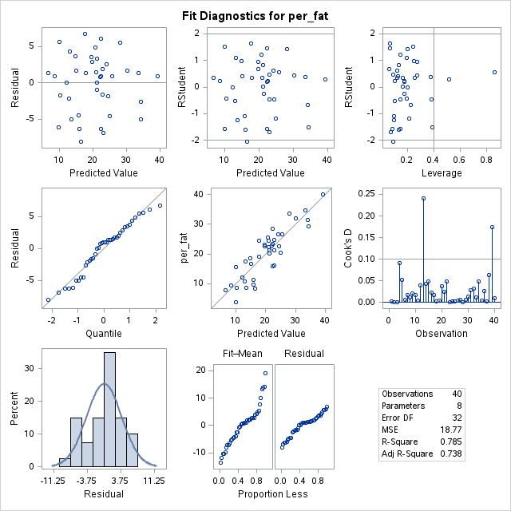

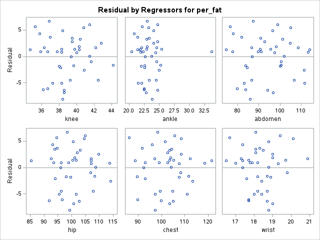

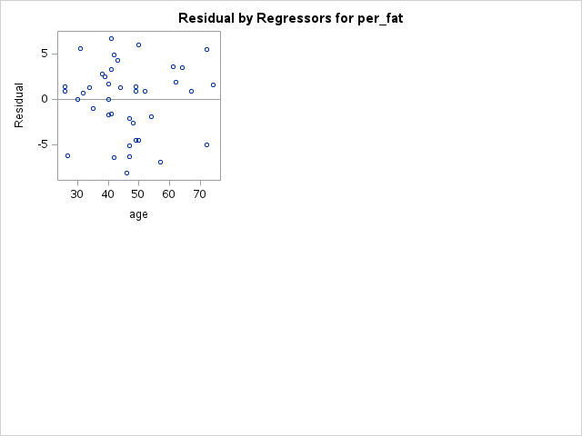

Stepwise Regression with various selection criteria

The REG Procedure

Model: MODEL1

Dependent Variable: per_fat

C(p) Selection Method

| Number of Observations Read | 40 |
| --- | --- |
| Number of Observations Used | 40 |

| Number in Model | C(p) | R-Square | Variables in Model |
| --- | --- | --- | --- |
| 4 | 2.5108 | 0.7640 | knee hip chest age |
| 4 | 3.3045 | 0.7582 | knee abdomen hip age |
| 3 | 3.3243 | 0.7436 | knee ankle abdomen |
| 5 | 3.4923 | 0.7714 | knee abdomen hip chest age |
| 5 | 3.5779 | 0.7708 | knee hip chest wrist age |

Stepwise Regression with various selection criteria

The REG Procedure

Model: MODEL1

Dependent Variable: per_fat

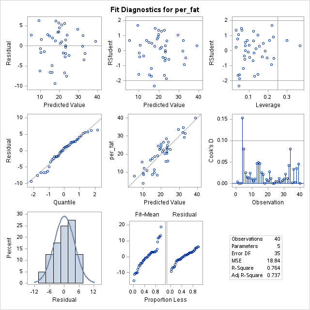

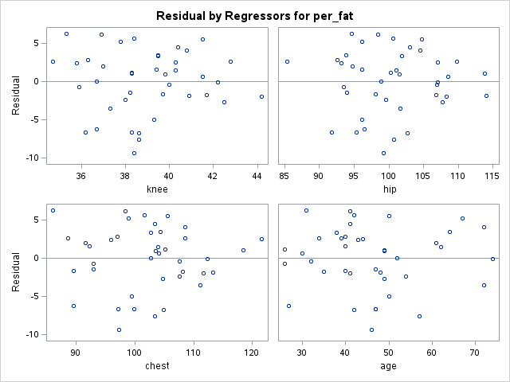

Stepwise Regression with various selection criteria

The GLMSELECT Procedure

| Data Set | WORK.NEW_BFAT |
| --- | --- |
| Dependent Variable | per_fat |
| Selection Method | Stepwise |
| Select Criterion | SBC |
| Stop Criterion | SBC |
| Choose Criterion | C(p) |
| Effect Hierarchy Enforced | None |

| Number of Observations Read | 40 |
| --- | --- |
| Number of Observations Used | 40 |

| Dimensions |  |
| --- | --- |
| Number of Effects | 11 |
| Number of Parameters | 11 |

Stepwise Regression with various selection criteria

The GLMSELECT Procedure

| Stepwise Selection Summary Step | Stepwise Selection Summary Effect Entered | Stepwise Selection Summary Effect Removed | Stepwise Selection Summary Number Effects In | Stepwise Selection Summary CP | Stepwise Selection Summary SBC |
| --- | --- | --- | --- | --- | --- |
| 0 | Intercept |  | 1 | 99.7544 | 173.5432 |
| 1 | abdomen |  | 2 | 7.0683 | 130.7247 |
| 2 | knee |  | 3 | 4.2578* | 129.6760* |

* Optimal Value of Criterion

| Selection stopped at a local minimum of the SBC criterion. |
| --- |

| Stop Details Candidate For | Stop Details Effect | Stop Details Candidate SBC | Stop Details | Stop Details Compare SBC |
| --- | --- | --- | --- | --- |
| Entry | ankle | 130.1737 | > | 129.6760 |
| Removal | knee | 130.7247 | > | 129.6760 |

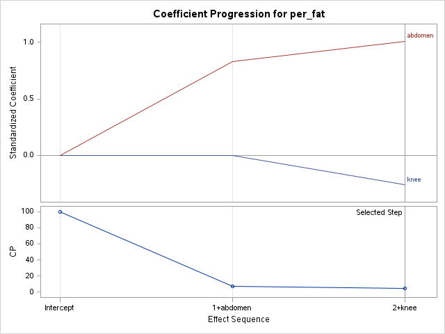

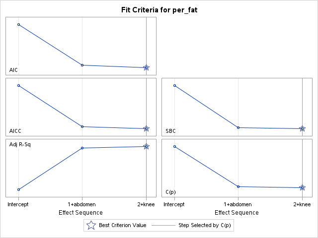

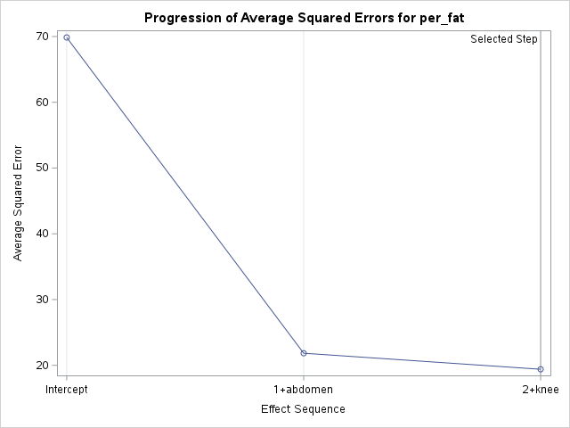

Stepwise Regression with various selection criteria

The GLMSELECT Procedure

Selected Model

The selected model, based on C(p), is the model at Step 2.

| Effects: | Intercept knee abdomen |
| --- | --- |

| Analysis of Variance Source | Analysis of Variance DF | Analysis of Variance Sum of Squares | Analysis of Variance Mean Square | Analysis of Variance F Value |
| --- | --- | --- | --- | --- |
| Model | 2 | 2018.05481 | 1009.02740 | 48.11 |
| Error | 37 | 775.96894 | 20.97213 |  |
| Corrected Total | 39 | 2794.02375 |  |  |

| Root MSE | 4.57953 |
| --- | --- |
| Dependent Mean | 20.28750 |
| R-Square | 0.7223 |
| Adj R-Sq | 0.7073 |
| AIC | 166.60932 |
| AICC | 167.75218 |
| BIC | 126.87841 |
| C(p) | 4.25778 |
| SBC | 129.67596 |

| Parameter Estimates Parameter | Parameter Estimates DF | Parameter Estimates Estimate | Parameter Estimates Standard Error | Parameter Estimates t Value |
| --- | --- | --- | --- | --- |
| Intercept | 1 | -15.275023 | 13.314855 | -1.15 |
| knee | 1 | -0.983639 | 0.456035 | -2.16 |
| abdomen | 1 | 0.788591 | 0.093850 | 8.40 |

Lasso Regression with Standardized Data

The GLMSELECT Procedure

| Data Set | WORK.DATA1 |
| --- | --- |
| Dependent Variable | per_fat |
| Selection Method | LASSO |
| Stop Criterion | SBC |
| Choose Criterion | C(p) |
| Effect Hierarchy Enforced | None |

| Number of Observations Read | 40 |
| --- | --- |
| Number of Observations Used | 40 |

| Dimensions |  |
| --- | --- |
| Number of Effects | 9 |
| Number of Parameters | 9 |

Lasso Regression with Standardized Data

The GLMSELECT Procedure

| LASSO Selection Summary Step | LASSO Selection Summary Effect Entered | LASSO Selection Summary Effect Removed | LASSO Selection Summary Number Effects In | LASSO Selection Summary CP | LASSO Selection Summary SBC |
| --- | --- | --- | --- | --- | --- |
| 0 | Intercept |  | 1 | 94.0674 | 2.6762 |
| 1 | abdomen |  | 2 | 12.7016 | -33.5390 |
| 2 | age |  | 3 | 5.0045* | -38.7315* |

* Optimal Value of Criterion

| Selection stopped at a local minimum of the SBC criterion. |
| --- |

| Stop Details Candidate For | Stop Details Effect | Stop Details Candidate SBC | Stop Details | Stop Details Compare SBC |
| --- | --- | --- | --- | --- |
| Entry | ankle | -35.0892 | > | -38.7315 |

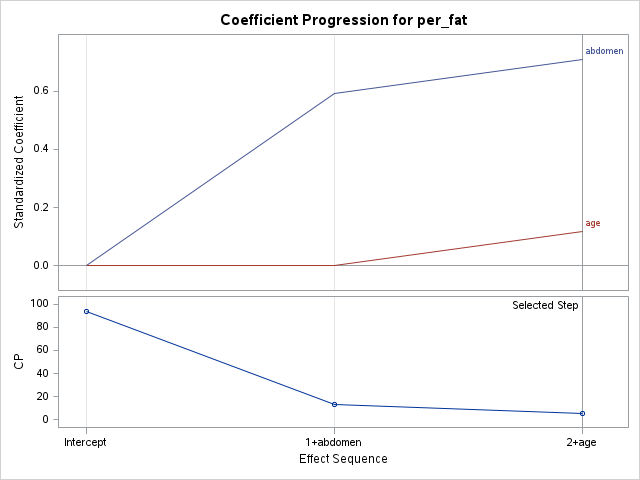

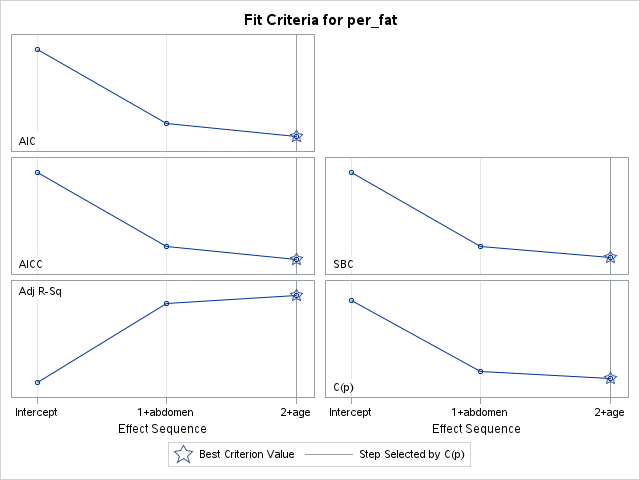

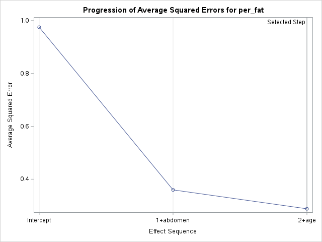

Lasso Regression with Standardized Data

The GLMSELECT Procedure

Selected Model

The selected model, based on C(p), is the model at Step 2.

| Effects: | Intercept abdomen age |
| --- | --- |

| Analysis of Variance Source | Analysis of Variance DF | Analysis of Variance Sum of Squares | Analysis of Variance Mean Square | Analysis of Variance F Value |
| --- | --- | --- | --- | --- |
| Model | 2 | 27.48183 | 13.74092 | 44.14 |
| Error | 37 | 11.51817 | 0.31130 |  |
| Corrected Total | 39 | 39.00000 |  |  |

| Root MSE | 0.55794 |
| --- | --- |
| Dependent Mean | 2.55351E-16 |
| R-Square | 0.7047 |
| Adj R-Sq | 0.6887 |
| AIC | -1.79816 |
| AICC | -0.65531 |
| BIC | -41.64633 |
| C(p) | 5.00447 |
| SBC | -38.73153 |

| Parameter Estimates Parameter | Parameter Estimates DF | Parameter Estimates Estimate |
| --- | --- | --- |
| Intercept | 1 | -1.15369E-15 |
| abdomen | 1 | 0.710335 |
| age | 1 | 0.118158 |

Correlation and Principal Component Analysis

The CORR Procedure

| 9 Variables: | per_fat thigh knee ankle abdomen biceps forearm age wrist |
| --- | --- |

| Simple Statistics Variable | Simple Statistics N | Simple Statistics Mean | Simple Statistics Std Dev | Simple Statistics Median | Simple Statistics Minimum | Simple Statistics Maximum |
| --- | --- | --- | --- | --- | --- | --- |
| per_fat | 40 | 20.28750 | 8.46414 | 21.25000 | 3.70000 | 40.10000 |
| thigh | 40 | 59.80500 | 4.38371 | 59.30000 | 51.70000 | 68.10000 |
| knee | 40 | 38.95000 | 2.22665 | 38.60000 | 34.70000 | 44.20000 |
| ankle | 40 | 23.36000 | 2.10016 | 22.95000 | 20.40000 | 33.70000 |
| abdomen | 40 | 93.68000 | 10.81974 | 93.40000 | 74.60000 | 113.90000 |
| biceps | 40 | 32.71500 | 2.69791 | 32.50000 | 27.90000 | 38.20000 |
| forearm | 40 | 28.95500 | 1.65327 | 29.05000 | 25.90000 | 33.10000 |
| age | 40 | 46.22500 | 12.51765 | 45.00000 | 26.00000 | 74.00000 |
| wrist | 40 | 18.35500 | 0.91370 | 18.25000 | 16.50000 | 20.90000 |

| Pearson Correlation Coefficients, N = 40 Prob > \|r\| under H0: Rho=0 | Pearson Correlation Coefficients, N = 40 Prob > \|r\| under H0: Rho=0 per_fat | Pearson Correlation Coefficients, N = 40 Prob > \|r\| under H0: Rho=0 thigh | Pearson Correlation Coefficients, N = 40 Prob > \|r\| under H0: Rho=0 knee | Pearson Correlation Coefficients, N = 40 Prob > \|r\| under H0: Rho=0 ankle | Pearson Correlation Coefficients, N = 40 Prob > \|r\| under H0: Rho=0 abdomen | Pearson Correlation Coefficients, N = 40 Prob > \|r\| under H0: Rho=0 biceps | Pearson Correlation Coefficients, N = 40 Prob > \|r\| under H0: Rho=0 forearm | Pearson Correlation Coefficients, N = 40 Prob > \|r\| under H0: Rho=0 age | Pearson Correlation Coefficients, N = 40 Prob > \|r\| under H0: Rho=0 wrist |
| --- | --- | --- | --- | --- | --- | --- | --- | --- | --- |
| per_fat | 1.00000 | 0.47372 0.0020 | 0.43853 0.0046 | 0.25554 0.1115 | 0.82907 <.0001 | 0.48619 0.0015 | 0.37513 0.0171 | 0.46200 0.0027 | 0.33300 0.0358 |
| thigh | 0.47372 0.0020 | 1.00000 | 0.80987 <.0001 | 0.25976 0.1055 | 0.70771 <.0001 | 0.69621 <.0001 | 0.66683 <.0001 | -0.10114 0.5346 | 0.43710 0.0048 |
| knee | 0.43853 0.0046 | 0.80987 <.0001 | 1.00000 | 0.37828 0.0161 | 0.69172 <.0001 | 0.66624 <.0001 | 0.64610 <.0001 | 0.15929 0.3262 | 0.67465 <.0001 |
| ankle | 0.25554 0.1115 | 0.25976 0.1055 | 0.37828 0.0161 | 1.00000 | 0.21690 0.1788 | 0.29313 0.0664 | 0.26096 0.1038 | 0.23404 0.1461 | 0.36971 0.0189 |
| abdomen | 0.82907 <.0001 | 0.70771 <.0001 | 0.69172 <.0001 | 0.21690 0.1788 | 1.00000 | 0.62800 <.0001 | 0.55114 0.0002 | 0.38013 0.0155 | 0.48249 0.0016 |
| biceps | 0.48619 0.0015 | 0.69621 <.0001 | 0.66624 <.0001 | 0.29313 0.0664 | 0.62800 <.0001 | 1.00000 | 0.81422 <.0001 | -0.07299 0.6544 | 0.52900 0.0004 |
| forearm | 0.37513 0.0171 | 0.66683 <.0001 | 0.64610 <.0001 | 0.26096 0.1038 | 0.55114 0.0002 | 0.81422 <.0001 | 1.00000 | -0.14458 0.3734 | 0.59679 <.0001 |
| age | 0.46200 0.0027 | -0.10114 0.5346 | 0.15929 0.3262 | 0.23404 0.1461 | 0.38013 0.0155 | -0.07299 0.6544 | -0.14458 0.3734 | 1.00000 | 0.40243 0.0100 |
| wrist | 0.33300 0.0358 | 0.43710 0.0048 | 0.67465 <.0001 | 0.36971 0.0189 | 0.48249 0.0016 | 0.52900 0.0004 | 0.59679 <.0001 | 0.40243 0.0100 | 1.00000 |

| Spearman Correlation Coefficients, N = 40 Prob > \|r\| under H0: Rho=0 | Spearman Correlation Coefficients, N = 40 Prob > \|r\| under H0: Rho=0 per_fat | Spearman Correlation Coefficients, N = 40 Prob > \|r\| under H0: Rho=0 thigh | Spearman Correlation Coefficients, N = 40 Prob > \|r\| under H0: Rho=0 knee | Spearman Correlation Coefficients, N = 40 Prob > \|r\| under H0: Rho=0 ankle | Spearman Correlation Coefficients, N = 40 Prob > \|r\| under H0: Rho=0 abdomen | Spearman Correlation Coefficients, N = 40 Prob > \|r\| under H0: Rho=0 biceps | Spearman Correlation Coefficients, N = 40 Prob > \|r\| under H0: Rho=0 forearm | Spearman Correlation Coefficients, N = 40 Prob > \|r\| under H0: Rho=0 age | Spearman Correlation Coefficients, N = 40 Prob > \|r\| under H0: Rho=0 wrist |
| --- | --- | --- | --- | --- | --- | --- | --- | --- | --- |
| per_fat | 1.00000 | 0.47933 0.0018 | 0.45617 0.0031 | 0.30345 0.0570 | 0.80955 <.0001 | 0.51088 0.0008 | 0.38282 0.0148 | 0.46023 0.0028 | 0.33012 0.0375 |
| thigh | 0.47933 0.0018 | 1.00000 | 0.82082 <.0001 | 0.58577 <.0001 | 0.75522 <.0001 | 0.65418 <.0001 | 0.67606 <.0001 | -0.04593 0.7784 | 0.50559 0.0009 |
| knee | 0.45617 0.0031 | 0.82082 <.0001 | 1.00000 | 0.68705 <.0001 | 0.72661 <.0001 | 0.64756 <.0001 | 0.66582 <.0001 | 0.12865 0.4288 | 0.69781 <.0001 |
| ankle | 0.30345 0.0570 | 0.58577 <.0001 | 0.68705 <.0001 | 1.00000 | 0.40165 0.0102 | 0.47763 0.0018 | 0.54526 0.0003 | 0.09175 0.5734 | 0.63911 <.0001 |
| abdomen | 0.80955 <.0001 | 0.75522 <.0001 | 0.72661 <.0001 | 0.40165 0.0102 | 1.00000 | 0.66814 <.0001 | 0.59345 <.0001 | 0.34460 0.0294 | 0.49035 0.0013 |
| biceps | 0.51088 0.0008 | 0.65418 <.0001 | 0.64756 <.0001 | 0.47763 0.0018 | 0.66814 <.0001 | 1.00000 | 0.79333 <.0001 | -0.07152 0.6610 | 0.54926 0.0002 |
| forearm | 0.38282 0.0148 | 0.67606 <.0001 | 0.66582 <.0001 | 0.54526 0.0003 | 0.59345 <.0001 | 0.79333 <.0001 | 1.00000 | -0.09070 0.5778 | 0.61477 <.0001 |
| age | 0.46023 0.0028 | -0.04593 0.7784 | 0.12865 0.4288 | 0.09175 0.5734 | 0.34460 0.0294 | -0.07152 0.6610 | -0.09070 0.5778 | 1.00000 | 0.31752 0.0459 |
| wrist | 0.33012 0.0375 | 0.50559 0.0009 | 0.69781 <.0001 | 0.63911 <.0001 | 0.49035 0.0013 | 0.54926 0.0002 | 0.61477 <.0001 | 0.31752 0.0459 | 1.00000 |

| Kendall Tau b Correlation Coefficients, N = 40 Prob > \|tau\| under H0: Tau=0 | Kendall Tau b Correlation Coefficients, N = 40 Prob > \|tau\| under H0: Tau=0 per_fat | Kendall Tau b Correlation Coefficients, N = 40 Prob > \|tau\| under H0: Tau=0 thigh | Kendall Tau b Correlation Coefficients, N = 40 Prob > \|tau\| under H0: Tau=0 knee | Kendall Tau b Correlation Coefficients, N = 40 Prob > \|tau\| under H0: Tau=0 ankle | Kendall Tau b Correlation Coefficients, N = 40 Prob > \|tau\| under H0: Tau=0 abdomen | Kendall Tau b Correlation Coefficients, N = 40 Prob > \|tau\| under H0: Tau=0 biceps | Kendall Tau b Correlation Coefficients, N = 40 Prob > \|tau\| under H0: Tau=0 forearm | Kendall Tau b Correlation Coefficients, N = 40 Prob > \|tau\| under H0: Tau=0 age | Kendall Tau b Correlation Coefficients, N = 40 Prob > \|tau\| under H0: Tau=0 wrist |
| --- | --- | --- | --- | --- | --- | --- | --- | --- | --- |
| per_fat | 1.00000 | 0.32990 0.0028 | 0.30859 0.0053 | 0.22251 0.0449 | 0.61104 <.0001 | 0.33205 0.0026 | 0.23149 0.0377 | 0.33335 0.0027 | 0.23179 0.0377 |
| thigh | 0.32990 0.0028 | 1.00000 | 0.63172 <.0001 | 0.45137 <.0001 | 0.56114 <.0001 | 0.48774 <.0001 | 0.48503 <.0001 | -0.03641 0.7438 | 0.33553 0.0027 |
| knee | 0.30859 0.0053 | 0.63172 <.0001 | 1.00000 | 0.50552 <.0001 | 0.57641 <.0001 | 0.48223 <.0001 | 0.48989 <.0001 | 0.07427 0.5058 | 0.52716 <.0001 |
| ankle | 0.22251 0.0449 | 0.45137 <.0001 | 0.50552 <.0001 | 1.00000 | 0.31784 0.0041 | 0.34975 0.0016 | 0.40707 0.0003 | 0.06789 0.5438 | 0.45217 <.0001 |
| abdomen | 0.61104 <.0001 | 0.56114 <.0001 | 0.57641 <.0001 | 0.31784 0.0041 | 1.00000 | 0.47558 <.0001 | 0.41302 0.0002 | 0.22540 0.0424 | 0.36675 0.0010 |
| biceps | 0.33205 0.0026 | 0.48774 <.0001 | 0.48223 <.0001 | 0.34975 0.0016 | 0.47558 <.0001 | 1.00000 | 0.62764 <.0001 | -0.05455 0.6241 | 0.39116 0.0005 |
| forearm | 0.23149 0.0377 | 0.48503 <.0001 | 0.48989 <.0001 | 0.40707 0.0003 | 0.41302 0.0002 | 0.62764 <.0001 | 1.00000 | -0.07218 0.5204 | 0.45850 <.0001 |
| age | 0.33335 0.0027 | -0.03641 0.7438 | 0.07427 0.5058 | 0.06789 0.5438 | 0.22540 0.0424 | -0.05455 0.6241 | -0.07218 0.5204 | 1.00000 | 0.22076 0.0496 |
| wrist | 0.23179 0.0377 | 0.33553 0.0027 | 0.52716 <.0001 | 0.45217 <.0001 | 0.36675 0.0010 | 0.39116 0.0005 | 0.45850 <.0001 | 0.22076 0.0496 | 1.00000 |

Correlation and Principal Component Analysis

The PRINCOMP Procedure

| Observations | 40 |
| --- | --- |
| Variables | 8 |

| Simple Statistics | Simple Statistics thigh | Simple Statistics knee | Simple Statistics ankle | Simple Statistics abdomen | Simple Statistics biceps | Simple Statistics forearm | Simple Statistics age | Simple Statistics wrist |
| --- | --- | --- | --- | --- | --- | --- | --- | --- |
| Mean | 59.80500000 | 38.95000000 | 23.36000000 | 93.68000000 | 32.71500000 | 28.95500000 | 46.22500000 | 18.35500000 |
| StD | 4.38370818 | 2.22664517 | 2.10015872 | 10.81973979 | 2.69791467 | 1.65327181 | 12.51765420 | 0.91369916 |

| Correlation Matrix | Correlation Matrix thigh | Correlation Matrix knee | Correlation Matrix ankle | Correlation Matrix abdomen | Correlation Matrix biceps | Correlation Matrix forearm | Correlation Matrix age | Correlation Matrix wrist |
| --- | --- | --- | --- | --- | --- | --- | --- | --- |
| thigh | 1.0000 | 0.8099 | 0.2598 | 0.7077 | 0.6962 | 0.6668 | -.1011 | 0.4371 |
| knee | 0.8099 | 1.0000 | 0.3783 | 0.6917 | 0.6662 | 0.6461 | 0.1593 | 0.6746 |
| ankle | 0.2598 | 0.3783 | 1.0000 | 0.2169 | 0.2931 | 0.2610 | 0.2340 | 0.3697 |
| abdomen | 0.7077 | 0.6917 | 0.2169 | 1.0000 | 0.6280 | 0.5511 | 0.3801 | 0.4825 |
| biceps | 0.6962 | 0.6662 | 0.2931 | 0.6280 | 1.0000 | 0.8142 | -.0730 | 0.5290 |
| forearm | 0.6668 | 0.6461 | 0.2610 | 0.5511 | 0.8142 | 1.0000 | -.1446 | 0.5968 |
| age | -.1011 | 0.1593 | 0.2340 | 0.3801 | -.0730 | -.1446 | 1.0000 | 0.4024 |
| wrist | 0.4371 | 0.6746 | 0.3697 | 0.4825 | 0.5290 | 0.5968 | 0.4024 | 1.0000 |

| Eigenvalues of the Correlation Matrix | Eigenvalues of the Correlation Matrix Eigenvalue | Eigenvalues of the Correlation Matrix Difference | Eigenvalues of the Correlation Matrix Proportion | Eigenvalues of the Correlation Matrix Cumulative |
| --- | --- | --- | --- | --- |
| 1 | 4.39402697 | 2.97672436 | 0.5493 | 0.5493 |
| 2 | 1.41730261 | 0.58913360 | 0.1772 | 0.7264 |
| 3 | 0.82816901 | 0.24613648 | 0.1035 | 0.8299 |
| 4 | 0.58203253 | 0.19161336 | 0.0728 | 0.9027 |
| 5 | 0.39041917 | 0.21644990 | 0.0488 | 0.9515 |
| 6 | 0.17396927 | 0.05420012 | 0.0217 | 0.9732 |
| 7 | 0.11976915 | 0.02545787 | 0.0150 | 0.9882 |
| 8 | 0.09431129 |  | 0.0118 | 1.0000 |

| Eigenvectors | Eigenvectors Prin1 | Eigenvectors Prin2 | Eigenvectors Prin3 | Eigenvectors Prin4 | Eigenvectors Prin5 | Eigenvectors Prin6 | Eigenvectors Prin7 | Eigenvectors Prin8 |
| --- | --- | --- | --- | --- | --- | --- | --- | --- |
| thigh | 0.404208 | -.237052 | -.115280 | 0.407865 | -.325031 | 0.106336 | 0.476021 | 0.507179 |
| knee | 0.429302 | 0.024187 | -.039453 | 0.130803 | -.540938 | -.270181 | -.643088 | -.131433 |
| ankle | 0.213791 | 0.309322 | 0.841908 | 0.340738 | 0.131026 | 0.091302 | 0.040033 | -.081211 |
| abdomen | 0.385338 | 0.137843 | -.435578 | 0.364530 | 0.327610 | 0.276500 | 0.086907 | -.564420 |
| biceps | 0.406302 | -.233101 | 0.037327 | -.134983 | 0.500812 | -.705042 | 0.094521 | 0.064330 |
| forearm | 0.397118 | -.273967 | 0.090584 | -.377010 | 0.281431 | 0.573251 | -.362082 | 0.279239 |
| age | 0.082848 | 0.783370 | -.270240 | -.013216 | 0.182398 | -.065103 | -.129982 | 0.501856 |
| wrist | 0.358435 | 0.292366 | 0.063154 | -.637981 | -.337579 | 0.031099 | 0.440174 | -.257599 |

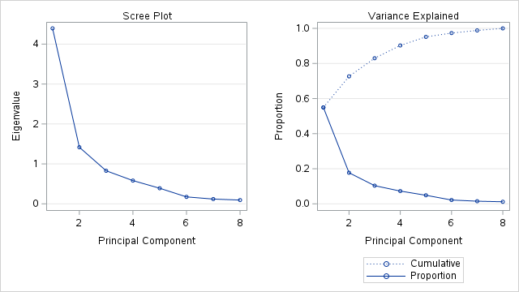

Correlation and Principal Component Analysis

The REG Procedure

Model: MODEL1

Dependent Variable: per_fat

C(p) Selection Method

| Number of Observations Read | 40 |
| --- | --- |
| Number of Observations Used | 40 |

| Number in Model | C(p) | R-Square | Variables in Model |
| --- | --- | --- | --- |
| 5 | 6.0597 | 0.7471 | Prin1 Prin2 Prin3 Prin4 Prin5 |
| 6 | 7.0000 | 0.7550 | Prin1 Prin2 Prin3 Prin4 Prin5 Prin6 |
| 4 | 14.6825 | 0.6682 | Prin1 Prin2 Prin3 Prin5 |
| 4 | 14.7117 | 0.6680 | Prin1 Prin3 Prin4 Prin5 |
| 5 | 15.6228 | 0.6761 | Prin1 Prin2 Prin3 Prin5 Prin6 |
| 5 | 15.6520 | 0.6759 | Prin1 Prin3 Prin4 Prin5 Prin6 |
| 4 | 15.8785 | 0.6594 | Prin1 Prin2 Prin4 Prin5 |
| 5 | 16.8188 | 0.6672 | Prin1 Prin2 Prin4 Prin5 Prin6 |
| 4 | 23.0823 | 0.6059 | Prin1 Prin2 Prin3 Prin4 |
| 3 | 23.3345 | 0.5892 | Prin1 Prin3 Prin5 |

Correlation and Principal Component Analysis

The REG Procedure

Model: MODEL1

Dependent Variable: per_fat

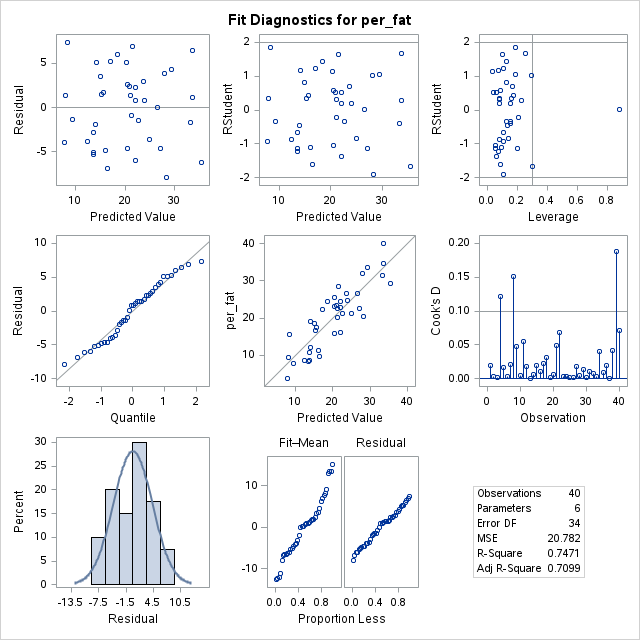

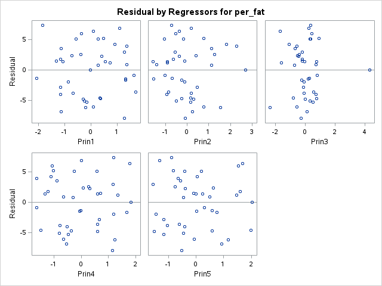

Correlation and Principal Component Analysis

Model selection with Proc Reg

The REG Procedure

Model: MODEL1

Dependent Variable: per_fat

C(p) Selection Method

| Number of Observations Read | 40 |
| --- | --- |
| Number of Observations Used | 40 |

| Model Index | Number in Model | C(p) | R-Square | Variables in Model |
| --- | --- | --- | --- | --- |
| 1 | 3 | 0.6216 | 0.8056 | abdomen ankle ht |
| 2 | 5 | 0.7757 | 0.8285 | abdomen ankle hip ht thigh |
| 3 | 2 | 0.8593 | 0.7922 | abdomen ht |
| 4 | 4 | 0.9998 | 0.8152 | abdomen hip ht thigh |
| 5 | 3 | 1.4852 | 0.8004 | abdomen biceps ht |
| 6 | 4 | 1.5560 | 0.8119 | abdomen age biceps ht |
| 7 | 4 | 1.5923 | 0.8117 | abdomen ankle ht thigh |
| 8 | 4 | 1.5924 | 0.8117 | abdomen biceps ht thigh |
| 9 | 5 | 1.6219 | 0.8235 | abdomen biceps hip ht thigh |
| 10 | 5 | 1.6343 | 0.8234 | abdomen ankle biceps ht thigh |

Correlation and Principal Component Analysis

Model selection with Proc Reg

The REG Procedure

Model: MODEL1

Dependent Variable: per_fat

C(p) Selection Method

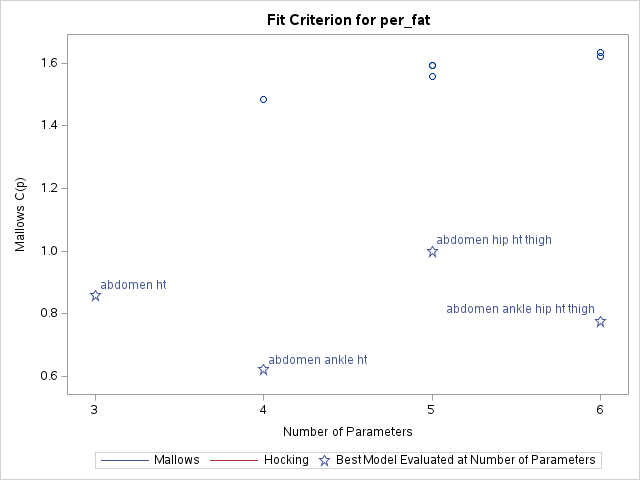

Correlation and Principal Component Analysis

Model selection with Proc Reg

The REG Procedure

Model: forward

Dependent Variable: per_fat

| Number of Observations Read | 40 |
| --- | --- |
| Number of Observations Used | 40 |

| Summary of Forward Selection Step | Summary of Forward Selection Variable Entered | Summary of Forward Selection Number Vars In | Summary of Forward Selection Partial R-Square | Summary of Forward Selection Model R-Square | Summary of Forward Selection C(p) | Summary of Forward Selection F Value | Summary of Forward Selection Pr > F |
| --- | --- | --- | --- | --- | --- | --- | --- |
| 1 | abdomen | 1 | 0.6874 | 0.6874 | 16.4597 | 83.54 | <.0001 |
| 2 | ht | 2 | 0.1049 | 0.7922 | 0.8593 | 18.68 | 0.0001 |

Correlation and Principal Component Analysis

Model selection with Proc Reg

The REG Procedure

Model: backward

Dependent Variable: per_fat

| Number of Observations Read | 40 |
| --- | --- |
| Number of Observations Used | 40 |

| Summary of Backward Elimination Step | Summary of Backward Elimination Variable Removed | Summary of Backward Elimination Number Vars In | Summary of Backward Elimination Partial R-Square | Summary of Backward Elimination Model R-Square | Summary of Backward Elimination C(p) | Summary of Backward Elimination F Value | Summary of Backward Elimination Pr > F |
| --- | --- | --- | --- | --- | --- | --- | --- |
| 1 | neck | 12 | 0.0000 | 0.8450 | 12.0000 | 0.00 | 0.9999 |
| 2 | wt | 11 | 0.0000 | 0.8450 | 10.0023 | 0.00 | 0.9616 |
| 3 | age | 10 | 0.0006 | 0.8444 | 8.1098 | 0.12 | 0.7362 |
| 4 | knee | 9 | 0.0021 | 0.8423 | 6.4574 | 0.39 | 0.5392 |
| 5 | chest | 8 | 0.0025 | 0.8398 | 4.8781 | 0.48 | 0.4951 |
| 6 | wrist | 7 | 0.0027 | 0.8371 | 3.3340 | 0.53 | 0.4738 |
| 7 | forearm | 6 | 0.0027 | 0.8344 | 1.7895 | 0.53 | 0.4705 |
| 8 | biceps | 5 | 0.0059 | 0.8285 | 0.7757 | 1.17 | 0.2870 |
| 9 | ankle | 4 | 0.0133 | 0.8152 | 0.9998 | 2.63 | 0.1142 |
| 10 | thigh | 3 | 0.0190 | 0.7963 | 2.1811 | 3.59 | 0.0663 |
| 11 | hip | 2 | 0.0040 | 0.7922 | 0.8593 | 0.71 | 0.4036 |

Correlation and Principal Component Analysis

Model selection with Proc Reg

The REG Procedure

Model: stepwise

Dependent Variable: per_fat

| Number of Observations Read | 40 |
| --- | --- |
| Number of Observations Used | 40 |

| Summary of Stepwise Selection Step | Summary of Stepwise Selection Variable Entered | Summary of Stepwise Selection Variable Removed | Summary of Stepwise Selection Number Vars In | Summary of Stepwise Selection Partial R-Square | Summary of Stepwise Selection Model R-Square | Summary of Stepwise Selection C(p) | Summary of Stepwise Selection F Value | Summary of Stepwise Selection Pr > F |
| --- | --- | --- | --- | --- | --- | --- | --- | --- |
| 1 | abdomen |  | 1 | 0.6874 | 0.6874 | 16.4597 | 83.54 | <.0001 |
| 2 | ht |  | 2 | 0.1049 | 0.7922 | 0.8593 | 18.68 | 0.0001 |

Correlation and Principal Component Analysis

Model selection with Proc Reg

The GLMSELECT Procedure

| Data Set | WORK.NEW_BFAT |
| --- | --- |
| Dependent Variable | per_fat |
| Selection Method | LASSO |
| Stop Criterion | SBC |
| Effect Hierarchy Enforced | None |

| Number of Observations Read | 40 |
| --- | --- |
| Number of Observations Used | 40 |

| Dimensions |  |
| --- | --- |
| Number of Effects | 14 |
| Number of Parameters | 14 |

Correlation and Principal Component Analysis

Model selection with Proc Reg

The GLMSELECT Procedure

| LASSO Selection Summary Step | LASSO Selection Summary Effect Entered | LASSO Selection Summary Effect Removed | LASSO Selection Summary Number Effects In | LASSO Selection Summary SBC |
| --- | --- | --- | --- | --- |
| 0 | Intercept |  | 1 | 173.5432 |
| 1 | abdomen |  | 2 | 163.2584 |
| 2 | chest |  | 3 | 141.3595 |
| 3 | ht |  | 4 | 138.3647 |
| 4 | age |  | 5 | 129.9056* |

* Optimal Value of Criterion

| Selection stopped at a local minimum of the SBC criterion. |
| --- |

| Stop Details Candidate For | Stop Details Effect | Stop Details Candidate SBC | Stop Details | Stop Details Compare SBC |
| --- | --- | --- | --- | --- |
| Entry | ankle | 132.8127 | > | 129.9056 |

Correlation and Principal Component Analysis

Model selection with Proc Reg

The GLMSELECT Procedure

Selected Model

The selected model is the model at the last step (Step 4).

| Effects: | Intercept abdomen age chest ht |
| --- | --- |

| Analysis of Variance Source | Analysis of Variance DF | Analysis of Variance Sum of Squares | Analysis of Variance Mean Square | Analysis of Variance F Value |
| --- | --- | --- | --- | --- |
| Model | 4 | 2145.03858 | 536.25965 | 28.92 |
| Error | 35 | 648.98517 | 18.54243 |  |
| Corrected Total | 39 | 2794.02375 |  |  |

| Root MSE | 4.30609 |
| --- | --- |
| Dependent Mean | 20.28750 |
| R-Square | 0.7677 |
| Adj R-Sq | 0.7412 |
| AIC | 163.46122 |
| AICC | 166.00667 |
| SBC | 129.90561 |

| Parameter Estimates Parameter | Parameter Estimates DF | Parameter Estimates Estimate |
| --- | --- | --- |
| Intercept | 1 | 2.491194 |
| abdomen | 1 | 0.437517 |
| age | 1 | 0.026989 |
| chest | 1 | 0.181826 |
| ht | 1 | -0.616173 |

Correlation and Principal Component Analysis

Model selection with Proc Reg

The GLMSELECT Procedure

| Data Set | WORK.NEW_BFAT |
| --- | --- |
| Dependent Variable | per_fat |
| Selection Method | LASSO |
| Stop at Specified Number of Steps | 3 |
| Choose Criterion | Validation ASE |
| Effect Hierarchy Enforced | None |
| Random Number Seed | 508545497 |

| Number of Observations Read | 40 |
| --- | --- |
| Number of Observations Used | 40 |
| Number of Observations Used for Training | 22 |
| Number of Observations Used for Validation | 10 |
| Number of Observations Used for Testing | 8 |

| Dimensions |  |
| --- | --- |
| Number of Effects | 14 |
| Number of Parameters | 14 |

Correlation and Principal Component Analysis

Model selection with Proc Reg

The GLMSELECT Procedure

| LASSO Selection Summary Step | LASSO Selection Summary Effect Entered | LASSO Selection Summary Effect Removed | LASSO Selection Summary Number Effects In | LASSO Selection Summary ASE | LASSO Selection Summary Validation ASE | LASSO Selection Summary Test ASE |
| --- | --- | --- | --- | --- | --- | --- |
| 0 | Intercept |  | 1 | 71.9259 | 92.7606 | 35.5064 |
| 1 | chest |  | 2 | 39.4752 | 60.1789 | 14.8626 |
| 2 | age |  | 3 | 15.0116 | 41.2834 | 17.8557 |
| 3 | biceps |  | 4 | 14.4022 | 40.8239* | 18.3565 |

* Optimal Value of Criterion

| Selection stopped at the specified number of steps (3). |
| --- |

Correlation and Principal Component Analysis

Model selection with Proc Reg

The GLMSELECT Procedure

Selected Model

The selected model, based on Validation ASE, is the model at Step 3.

| Effects: | Intercept age biceps chest |
| --- | --- |

| Analysis of Variance Source | Analysis of Variance DF | Analysis of Variance Sum of Squares | Analysis of Variance Mean Square | Analysis of Variance F Value |
| --- | --- | --- | --- | --- |
| Model | 3 | 1265.52032 | 421.84011 | 23.96 |
| Error | 18 | 316.84923 | 17.60273 |  |
| Corrected Total | 21 | 1582.36955 |  |  |

| Root MSE | 4.19556 |
| --- | --- |
| Dependent Mean | 20.29545 |
| R-Square | 0.7998 |
| Adj R-Sq | 0.7664 |
| AIC | 90.68244 |
| AICC | 94.43244 |
| SBC | 71.04661 |
| ASE (Train) | 14.40224 |
| ASE (Validate) | 40.82393 |
| ASE (Test) | 18.35645 |

| Parameter Estimates Parameter | Parameter Estimates DF | Parameter Estimates Estimate |
| --- | --- | --- |
| Intercept | 1 | -52.726583 |
| age | 1 | 0.168651 |
| biceps | 1 | 0.049829 |
| chest | 1 | 0.625916 |

Correlation and Principal Component Analysis

Model selection with Proc Reg

The GLMSELECT Procedure

| Data Set | WORK.NEW_BFAT |
| --- | --- |
| Dependent Variable | per_fat |
| Selection Method | ELASTICNET |
| Stop at Specified Number of Steps | 5 |
| Choose Criterion | Validation ASE |
| Effect Hierarchy Enforced | None |
| Random Number Seed | 508597436 |

| Number of Observations Read | 40 |
| --- | --- |
| Number of Observations Used | 40 |
| Number of Observations Used for Training | 18 |
| Number of Observations Used for Validation | 11 |
| Number of Observations Used for Testing | 11 |

| Dimensions |  |
| --- | --- |
| Number of Effects | 14 |
| Number of Parameters | 14 |

Correlation and Principal Component Analysis

Model selection with Proc Reg

The GLMSELECT Procedure

| Elastic Net Selection Summary Step | Elastic Net Selection Summary Effect Entered | Elastic Net Selection Summary Effect Removed | Elastic Net Selection Summary Number Effects In | Elastic Net Selection Summary ASE | Elastic Net Selection Summary Validation ASE | Elastic Net Selection Summary Test ASE |
| --- | --- | --- | --- | --- | --- | --- |
| 0 | Intercept |  | 1 | 57.2484 | 82.9401 | 79.5125 |
| 1 | abdomen |  | 2 | 42.0912 | 55.5908 | 61.2583 |
| 2 | chest |  | 3 | 31.4296 | 37.7634 | 49.3346 |
| 3 | hip |  | 4 | 20.6013 | 24.4940 | 37.3287 |
| 4 | ht |  | 5 | 17.2712 | 21.3277* | 30.3900 |
| 5 | wrist |  | 6 | 15.2280 | 23.4226 | 30.0476 |

* Optimal Value of Criterion

| Selection stopped at the specified number of steps (5). |
| --- |

Correlation and Principal Component Analysis

Model selection with Proc Reg

The GLMSELECT Procedure

Selected Model

The selected model, based on Validation ASE, is the model at Step 4.

| Effects: | Intercept abdomen chest hip ht |
| --- | --- |

| Analysis of Variance Source | Analysis of Variance DF | Analysis of Variance Sum of Squares | Analysis of Variance Mean Square | Analysis of Variance F Value |
| --- | --- | --- | --- | --- |
| Model | 4 | 719.58929 | 179.89732 | 7.52 |
| Error | 13 | 310.88182 | 23.91399 |  |
| Corrected Total | 17 | 1030.47111 |  |  |

| Root MSE | 4.89019 |
| --- | --- |
| Dependent Mean | 19.52222 |
| R-Square | 0.6983 |
| Adj R-Sq | 0.6055 |
| AIC | 81.28274 |
| AICC | 88.91910 |
| SBC | 65.73460 |
| ASE (Train) | 17.27121 |
| ASE (Validate) | 21.32771 |
| ASE (Test) | 30.38998 |

| Parameter Estimates Parameter | Parameter Estimates DF | Parameter Estimates Estimate |
| --- | --- | --- |
| Intercept | 1 | -25.203105 |
| abdomen | 1 | 0.272671 |
| chest | 1 | 0.158727 |
| hip | 1 | 0.221006 |
| ht | 1 | -0.267289 |

Robust regression with Bodyfat data

The REG Procedure

Model: MODEL1

Dependent Variable: density

| Number of Observations Read | 40 |
| --- | --- |
| Number of Observations Used | 40 |

| Analysis of Variance Source | Analysis of Variance DF | Analysis of Variance Sum of Squares | Analysis of Variance Mean Square | Analysis of Variance F Value | Analysis of Variance Pr > F |
| --- | --- | --- | --- | --- | --- |
| Model | 1 | 0.00984 | 0.00984 | 86.50 | <.0001 |
| Error | 38 | 0.00432 | 0.00011374 |  |  |
| Corrected Total | 39 | 0.01416 |  |  |  |

| Root MSE | 0.01066 | R-Square | 0.6948 |
| --- | --- | --- | --- |
| Dependent Mean | 1.05313 | Adj R-Sq | 0.6868 |
| Coeff Var | 1.01269 |  |  |

| Parameter Estimates Variable | Parameter Estimates DF | Parameter Estimates Parameter Estimate | Parameter Estimates Standard Error | Parameter Estimates t Value | Parameter Estimates Pr > \|t\| |
| --- | --- | --- | --- | --- | --- |
| Intercept | 1 | 1.67474 | 0.06686 | 25.05 | <.0001 |
| labdomen | 1 | -0.13712 | 0.01474 | -9.30 | <.0001 |

Robust regression with Bodyfat data

Tukey Biweigth using IRLS

The NLIN Procedure

Dependent Variable density

Method: Gauss-Newton

| Iterative Phase Iter | Iterative Phase b0 | Iterative Phase b1 | Iterative Phase Weighted SS |
| --- | --- | --- | --- |
| 0 | 1.6000 | -0.1200 | 0.00481 |
| 1 | 1.6747 | -0.1371 | 0.00432 |

| NOTE: Convergence criterion met. |
| --- |

| Estimation Summary |  |
| --- | --- |
| Method | Gauss-Newton |
| Iterations | 1 |
| R | 7.594E-8 |
| PPC(b1) | 2.679E-8 |
| RPC(b1) | 0.14266 |
| Object | . |
| Objective | 0.004322 |
| Observations Read | 40 |
| Observations Used | 40 |
| Observations Missing | 0 |

| Source | DF | Sum of Squares | Mean Square | F Value | Approx Pr > F |
| --- | --- | --- | --- | --- | --- |
| Model | 1 | 0.00984 | 0.00984 | 86.50 | <.0001 |
| Error | 38 | 0.00432 | 0.000114 |  |  |
| Corrected Total | 39 | 0.0142 |  |  |  |

| Parameter | Estimate | Approx Std Error | Approximate 95% Confidence Limits |  |
| --- | --- | --- | --- | --- |
| b0 | 1.6747 | 0.0669 | 1.5394 | 1.8101 |
| b1 | -0.1371 | 0.0147 | -0.1670 | -0.1073 |

| Approximate Correlation Matrix | Approximate Correlation Matrix b0 | Approximate Correlation Matrix b1 |
| --- | --- | --- |
| b0 | 1.0000000 | -0.9996819 |
| b1 | -0.9996819 | 1.0000000 |

Robust regression with Bodyfat data

Tukey Biweigth using IRLS

The ROBUSTREG Procedure

| Model Information |  |
| --- | --- |
| Data Set | WORK.NEW_BFAT |
| Dependent Variable | density |
| Number of Independent Variables | 1 |
| Number of Observations | 40 |
| Method | M Estimation |

| Number of Observations Read | 40 |
| --- | --- |
| Number of Observations Used | 40 |

| Parameter Information Parameter | Parameter Information Effect |
| --- | --- |
| Intercept | Intercept |
| labdomen | labdomen |

| Summary Statistics Variable | Summary Statistics Q1 | Summary Statistics Median | Summary Statistics Q3 | Summary Statistics Mean | Summary Statistics Standard Deviation | Summary Statistics MAD |
| --- | --- | --- | --- | --- | --- | --- |
| labdomen | 4.4450 | 4.5369 | 4.6136 | 4.5334 | 0.1158 | 0.1206 |
| density | 1.0418 | 1.0504 | 1.0690 | 1.0531 | 0.0191 | 0.0176 |

| Parameter Estimates Parameter | Parameter Estimates DF | Parameter Estimates Estimate | Parameter Estimates Standard Error | Parameter Estimates 95% Confidence Limits | Parameter Estimates 95% Confidence Limits | Parameter Estimates Chi-Square | Parameter Estimates Pr > ChiSq |
| --- | --- | --- | --- | --- | --- | --- | --- |
| Intercept | 1 | 1.6805 | 0.0708 | 1.5418 | 1.8192 | 564.11 | <.0001 |
| labdomen | 1 | -0.1384 | 0.0156 | -0.1689 | -0.1078 | 78.64 | <.0001 |
| Scale | 1 | 0.0133 |  |  |  |  |  |

| Diagnostics Summary Observation Type | Diagnostics Summary Proportion | Diagnostics Summary Cutoff |
| --- | --- | --- |
| Outlier | 0.0000 | 3.0000 |
| Leverage | 0.0000 | 2.2414 |

| Goodness-of-Fit Statistic | Goodness-of-Fit Value |
| --- | --- |
| R-Square | 0.6419 |
| AICR | 25.5011 |
| BICR | 30.5718 |
| Deviance | 0.0041 |

Quantile regression with Bodyfat data

The QUANTREG Procedure

| Model Information |  |
| --- | --- |
| Data Set | WORK.NEW_BFAT |
| Dependent Variable | density |
| Number of Independent Variables | 1 |
| Number of Observations | 40 |
| Optimization Algorithm | Interior |

| Number of Observations Read | 40 |
| --- | --- |
| Number of Observations Used | 40 |

| Summary Statistics Variable | Summary Statistics Q1 | Summary Statistics Median | Summary Statistics Q3 | Summary Statistics Mean | Summary Statistics Standard Deviation | Summary Statistics MAD |
| --- | --- | --- | --- | --- | --- | --- |
| labdomen | 4.4450 | 4.5369 | 4.6136 | 4.5334 | 0.1158 | 0.1206 |
| density | 1.0418 | 1.0504 | 1.0690 | 1.0531 | 0.0191 | 0.0176 |

| Quantile Level and Objective Function |  |
| --- | --- |
| Quantile Level | 0.5 |
| Objective Function | 0.1725 |
| Predicted Value at Mean | 1.0525 |

| Parameter Estimates Parameter | Parameter Estimates DF | Parameter Estimates Estimate |
| --- | --- | --- |
| Intercept | 1 | 1.6788 |
| labdomen | 1 | -0.1381 |